# LLM-autocorprophagy

Predictions, retrodictions and prognoses of LLMs’ impact on written language.

Aleksander Dietrichson, PhD

## Disclaimer & Reverse Disclaimer

- *Claude code* was used to generate the source code for data collection and for running the experiment as reported.
- No AI tools were used in the creation of this presentation. R and quarto code for data analysis written exclusively written by the author<sup>1</sup>.
- Source-code, AI prompts and data available at: https://github.com/dietrichson/ILA-2026
[^1]: With the exception of spell-checker.

## How LLMs Work

## Experiment: Data

- Five articles, 1600-2200 words each.
- One from the *New Yorker* four from the *New York Times*.
- Chosen for length, from the latest edition of each publication (last week of april 2026)

## Experiment: Method

### Step 1: Summarization task

This is the text of an published article. Your task is to summarize this. Aim for 500 words. The output filename should have the same name as the input-file with “_summary” interjected.

### Step 2: Expansion task

This is a short article, we would like to make it longer. Please add verbiage so that the article is around 1600 words long. The output filename should be the same as the input-file with “_expanded” instead of “_summary”

## Experiment: Aparatus

Claude code was used, with Opus 4.7

## Results

| Publication | Original | Processed | Loss |
| --- | --- | --- | --- |
| New Yorker | 792 | 753 | 4.9% |
| New York Times 1 | 818 | 690 | 15.6% |
| New York Times 2 | 992 | 741 | 25.3% |
| New York Times 3 | 820 | 640 | 22.0% |
| New York Times 4 | 921 | 677 | 26.5% |

Average loss is 19%

## Results

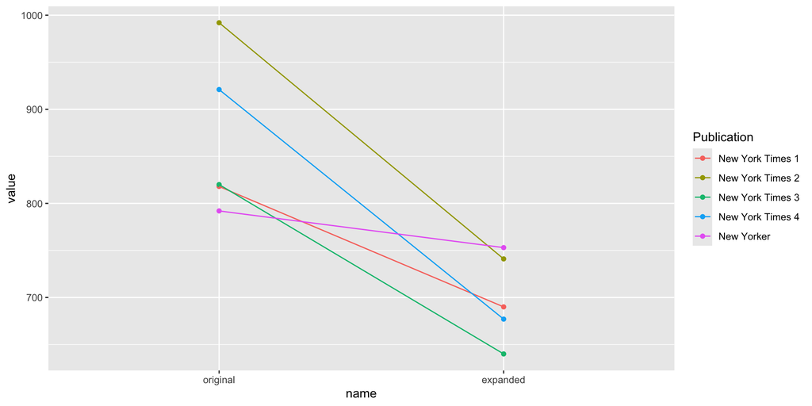

## Empirical Research

- Random sample of 15 thousand webpages
- Retrieved from https://commoncrawl.org/
- English language
- 1000 from each of the years 2012 through 2026
- Calculated Type/Token ratio for each document

## Results

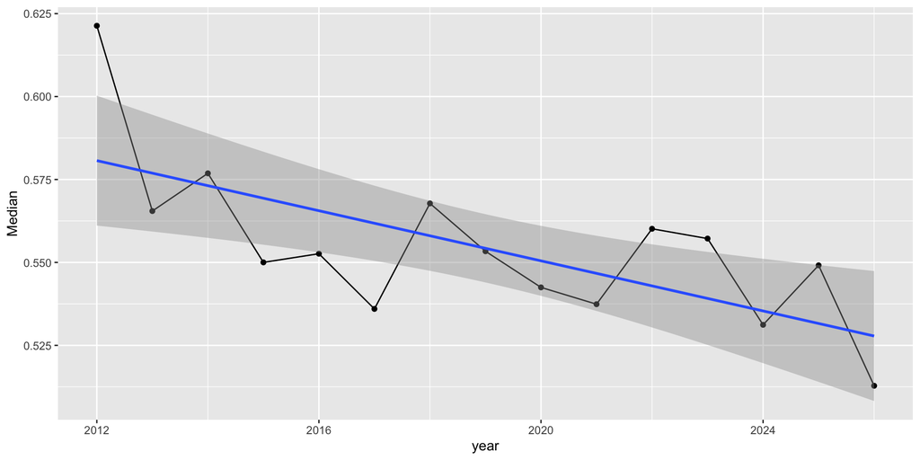

Median TRR over Year